# Ramada by Wyndham Hamilton City Center: Review Benchmarking and Price Prediction

## 5.6 Word clouds for n = 1 to 6

A word cloud shows the repeated n-grams at a glance: bigger text means the n-gram appears in more reviews. The colours are the same as in the bar diagrams (green = happy guests, red = unhappy guests, grey = nutral). Longer n-grams need smaller text to fit, so we show fewer phrases as n grows.

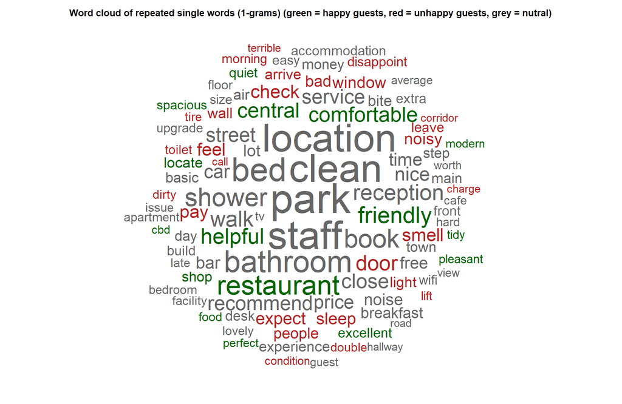

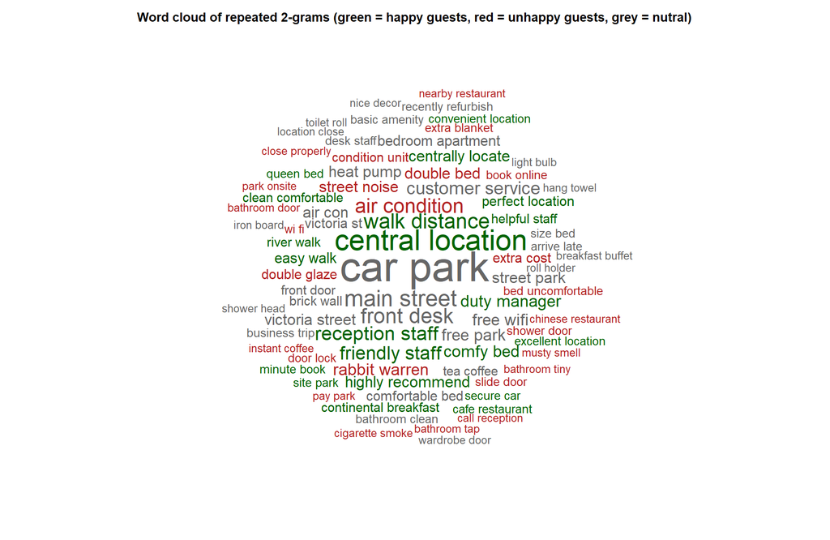

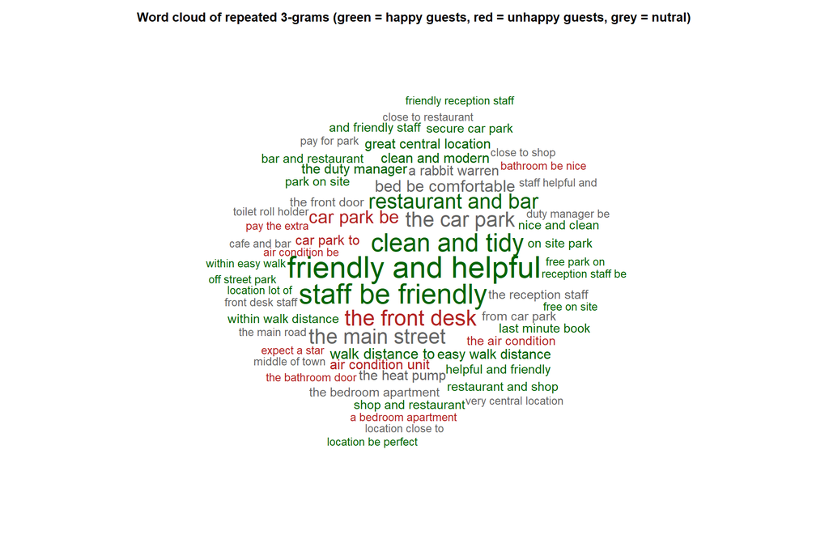

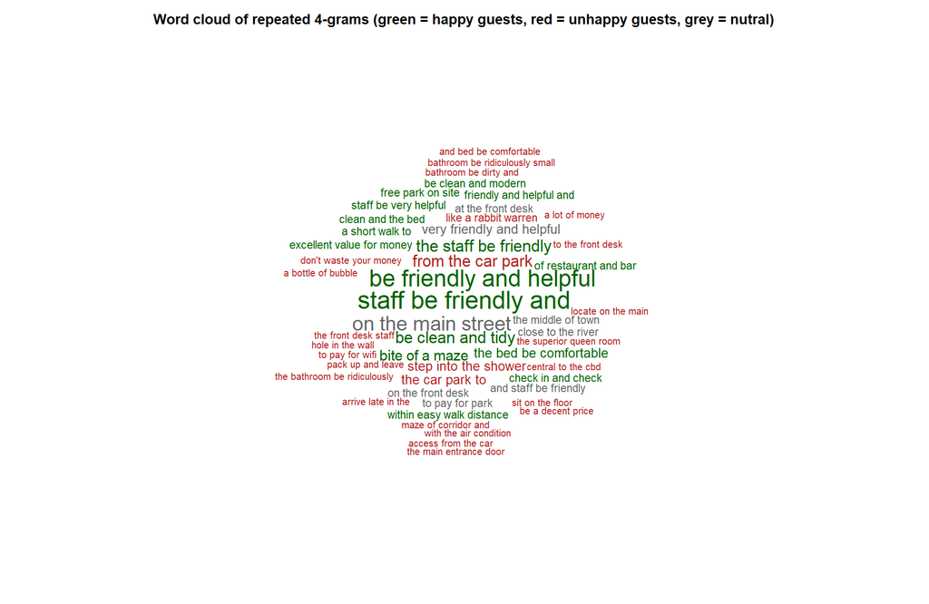

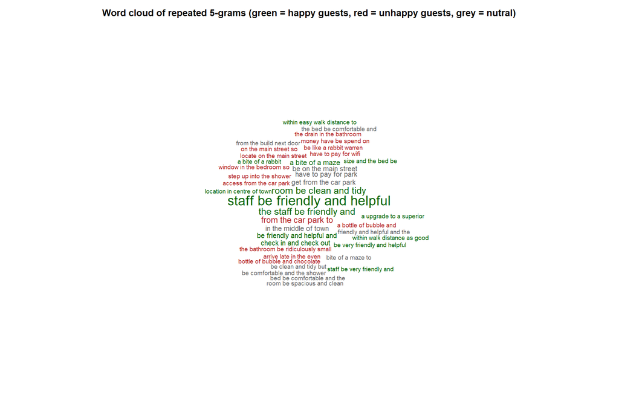

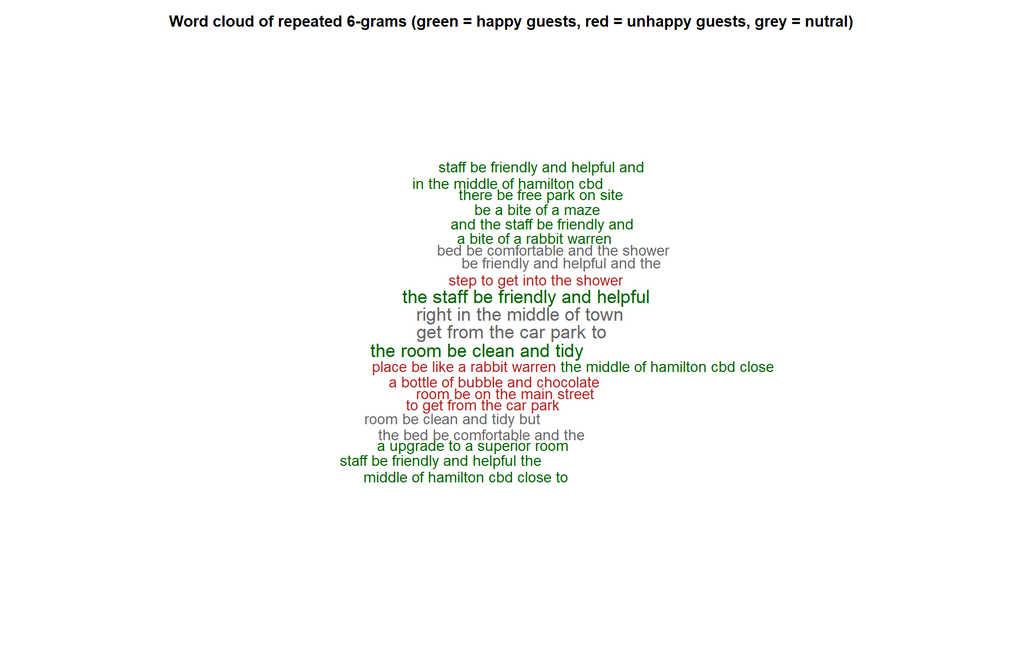

**Interpretation:**

- n = 1: the biggest words (location, bed, clean, park, staff, bathroom, restaurant, shower, book) are mostly **grey**, because happy and unhappy guests both use them. Colour appears in the smaller words: **red** for door, smell, noisy, window, pay, dirty, disappoint, terrible, **green** for friendly, helpful, comfortable, central, restaurant, spacious, quiet. Single words show what guests talk about, but not whether the comment is good or bad.
- n = 2 to 4: the colours become much clearer, because a phrase carries context. In the 4-gram cloud the **green** phrases are staff be friendly and helpful, be clean and tidy, within easy walk distance, free park on site and excellent value for money. The **red** phrases are from the car park, step into the shower, bathroom be ridiculously small, to pay for wifi, don’t waste your money, a lot of money, pack up and leave, hole in the wall and the main entrance door.
- n = 5 and n = 6: the clouds are smaller, because fewer phrases repeat, but the phrases are almost complete sentences. The same messages appear: friendly staff and clean rooms (green); getting from the car park, the shower step and the rabbit-warren layout (red).
- Overall: word clouds are most useful for n = 2 to 4: the phrases are frequent enough to be reliable and long enough to show whether guests are happy or unhappy.